Ali Emre Öz

213950785

### EECS 461 - MACHINE LEARNING PROJECT INTERIM REPORT

In my project, I will try to predict the genre of the movie using data about movie; like actors, actress, director, screenwriter, duraton of the movie, release date of movie, budget and revenue of movie etc.

At the beginning, for the dataset I will try to collect all the data from Open Movie Database (OMDB) API and The Movie Database(TMDB) API by using request. The Movie Database (TMDb) is a community built movie database and they provide a great application programming interface (API) for accessing information relating to movies as well as ancillary information on reviews, cast members, and genres. The OMDb API is a RESTful web service to obtain movie information, all content and images on the site are contributed and maintained by their users. For accessing TMDb and OMDb API, I need APIkey for both API.

```python
TMBD_APIKEY = "e9b448de2b20acefac2cfadd1f2bd666"
OMDB_APIKEY = "ff21610b"
```

##### TMDB API

IN TMDb, once you have a valid key, the queries to be invoked are based on formatting a HTTP request to the API using a predefined searches and the output type of this searches are json and the formation of this json result is like that:

```python
import json
import requests
import pandas as pd
import re
import matplotlib
import matplotlib.pyplot as plt
%matplotlib inline
from wordcloud import WordCloud
```

```python
url = "https://api.themoviedb.org/3/movie/935?api_key="+TMBD_APIKEY
r = requests.get(url)
json_data = r.json()
tmdb_keys = []
tmdb_values = []
for k in json_data.keys():
    tmdb_keys.append(k)
    tmdb_values.append(json_data[k])
tmdb_keys
```

```
['adult',
 'backdrop_path',
 'belongs_to_collection',
 'budget',
 'genres',
 'homepage',
 'id',
 'imdb_id',
 'original_language',
 'original_title',
 'overview',
 'popularity',
 'poster_path',
 'production_companies',
 'production_countries',
 'release_date',
 'revenue',
 'runtime',
 'spoken_languages',
 'status',
 'tagline',
 'title',
 'video',
 'vote_average',
 'vote_count']
```

##### OMDB API

For accessing OMDB API, I need IMDB id of movie and this can be found from TMDB API. In OMDb, it works like TMDb API but the the content of the data changes and the formation of this OMDb API json result is like that:

```python
url = "http://www.omdbapi.com/?apikey="+OMDB_APIKEY+"&i=tt0057012"
r = requests.get(url)
json_data = r.json()
omdb_keys = []
omdb_values = []
for k in json_data.keys():
    omdb_keys.append(k)
    omdb_values.append(json_data[k])
omdb_keys
```

```
['Title',
 'Year',
 'Rated',
 'Released',
 'Runtime',
 'Genre',
 'Director',
 'Writer',
 'Actors',
 'Plot',
 'Language',
 'Country',
 'Awards',
 'Poster',
 'Ratings',
 'Metascore',
 'imdbRating',
 'imdbVotes',
 'imdbID',
 'Type',
 'DVD',
 'BoxOffice',
 'Production',
 'Website',
 'Response']
```

##### Labels

For my final evoulation about the genres of movies, I will use supervised learning. So, I need labels. For finding all labels, I can use TMDB API.

```python
url = "https://api.themoviedb.org/3/genre/movie/list?api_key="+TMBD_APIKEY+"&language=en-US"
r = requests.get(url)
json_data = r.json()

genres = []
for x in json_data['genres']:
    genres.append(x["name"])
for i in genres:
    print(i)
```

```
Action
Adventure
Animation
Comedy
Crime
Documentary
Drama
Family
Fantasy
History
Horror
Music
Mystery
Romance
Science Fiction
TV Movie
Thriller
War
Western
```

### Final Shape of The Datas

After parsing all the data about movies from APIs, I planned to have **imdbId** (as an id), **title, budget, overview, revenue, runtime, year, rated, director, writer, actors** and **all genres as columns**.

For feature we can use **budget**, **title**, **overview**, **revenue**, **runtime**, **year**, **rated**, **director** (first two director as *director1* and *director2*), **writer** (first three writer as *writer1*, *writer2*, *writer3*), **actor** (first five actor as *actor1*, *actor2*, *actor3*, *actor4*, *actor5*) and **genres** (*Action*, *Adventure*, *Animation*, *Comedy*, *Crime*, *Documentary*, *Drama*, *Family*, *Fantasy*, *History*, *Horror*, *Music*, *Mystery*, *Romance*, *Science Fiction*, *TV Movie*, *Thriller*, *War* ,*Western*)

For text based feature like title and overview; we have to use a method for transforming text to numerical features. Further research will be conducted for it.

### Example Usage of APIs

```python
keys = ['Title', 'Year', 'Rated', 'Runtime', 'Genre', 'Director', 'Writer', 'Actors', 'Plot', 'imdbRating', 'imdbID', 'BoxOffice']
genres = ['Action', 'Adventure', 'Animation', 'Comedy', 'Crime', 'Documentary', 'Drama', 'Family', 'Fantasy', 'History', 'Horror', 'Music', 'Mystery','Romance', 'Science Fiction', 'TV Movie', 'Thriller', 'War', 'Western']
```

```python
import json
import requests
import pandas as pd
import re
import csv
import time
%pylab inline
```

```python
url =  "https://api.themoviedb.org/3/movie/24428?api_key="+TMBD_APIKEY
r = requests.get(url)
json_data = r.json()
avengers = {}
for k in json_data.keys():
    avengers["imdb_id"] = json_data["imdb_id"]
    avengers["title"] = json_data["title"]
    avengers["budget"] = json_data["budget"]
    avengers["overview"] = json_data["overview"]
    avengers["revenue"] = json_data["revenue"]
    avengers["runtime"] = json_data["runtime"]
    avengers["genres"] = json_data["genres"]

url = "http://www.omdbapi.com/?apikey="+OMDB_APIKEY+"&i="+avengers["imdb_id"]
r = requests.get(url)
json_data = r.json()
for k in json_data.keys():
    avengers["year"] = json_data["Year"]
    avengers["rated"] = json_data["Rated"]
    avengers["director"] = ((re.sub(r'\([^)]*\)', '', json_data["Director"])).split(","))
    avengers["writer"] = ((re.sub(r'\([^)]*\)', '', json_data["Writer"])).split(","))
    avengers["actors"] = ((re.sub(r'\([^)]*\)', '', json_data["Actors"])).split(","))
    avengers["imdbrating"] = json_data["imdbRating"]

avengers["writer"] = [x.rstrip() for x in avengers["writer"]]
avengers["writer"] = [x.lstrip() for x in avengers["writer"]]
avengers["actors"] = [x.rstrip() for x in avengers["actors"]]
avengers["actors"] = [x.lstrip() for x in avengers["actors"]]
avengers["director"] = [x.rstrip() for x in avengers["director"]]
avengers["director"] = [x.lstrip() for x in avengers["director"]]
avengers["writer"] = list(set(avengers["writer"]))
avengers["director"] = list(set(avengers["director"]))
avengers["actors"] = list(set(avengers["actors"]))
avengers_genre_temp = avengers["genres"]
del avengers["genres"]
avengers_genre = []

for i in range(1,3,1):
    try:
        avengers["director%s"%(i)] = (avengers["director"][i-1])
    except:
        avengers["director%s"%(i)] = None
for i in range(1,4,1):
    try:
        avengers["writer%s"%(i)] = (avengers["writer"][i-1])
    except:
        avengers["writer%s"%(i)] = None
for i in range(1,6,1):
    try:
        avengers["actor%s"%(i)] = (avengers["actors"][i-1])
    except:
        avengers["actor%s"%(i)] = None
del avengers["actors"]
del avengers["writer"]
del avengers["director"]
for i in avengers_genre_temp:
    avengers_genre.append(i["name"])
avengers_genre
genre_matrix = {}
for i in genres:
    if i in avengers_genre:
        genre_matrix[i] = 1
    if i not in avengers_genre:
        genre_matrix[i] = 0
avengers_genre_df = pd.DataFrame(genre_matrix, index = ["Avengers"])
avengers_df = pd.DataFrame(avengers, index = ["Avengers"])
avengers = pd.concat([avengers_df, avengers_genre_df], axis=1)
```

```python
pd.options.display.max_columns = None
avengers
```

|  | actor1 | actor2 | actor3 | actor4 | actor5 | budget | director1 | director2 | imdb_id | imdbrating | overview | rated | revenue | runtime | title | writer1 | writer2 | writer3 | year | Action | Adventure | Animation | Comedy | Crime | Documentary | Drama | Family | Fantasy | History | … |
| --- | --- | --- | --- | --- | --- | --- | --- | --- | --- | --- | --- | --- | --- | --- | --- | --- | --- | --- | --- | --- | --- | --- | --- | --- | --- | --- | --- | --- | --- | --- |
| Avengers | Chris Hemsworth | Mark Ruffalo | Robert Downey Jr. | Chris Evans | None | 220000000 | Joss Whedon | None | tt0848228 | 8.1 | When an unexpected enemy emerges and threatens... | PG-13 | 1519557910 | 143 | The Avengers | Joss Whedon | Zak Penn | None | 2012 | 1 | 1 | 0 | 0 | 0 | 0 | 0 | 0 | 0 | 0 | … |

I write function that takes tmbd_id as an input and returns movies data as in the example above. But the data set must be large for the efficiency of the results I want to achieve and it is hard to use these APIs because they do not work very stable and there are certain request limits for fixed times.

After a long time on working with these APIs, I noticed that it would be very troublesome to draw thousands of data belonging to the movies, and that I would struggle a lot because of the restriction of these APIs (When you send too many requests, you have a risk of being baned.). Even if everything goes perfect, it took a lot of time to get thousands of movies. So I decided to use these APIs just for simple operations. And, I found a pre-prepared dataset.

## Better Dataset

I found a dataset that is created from TMDB API and IMDBpy library. It contains approximately 10000 movies. It seperated into three files:

- First file is actually contains what I want to achieve. (tmdb_id / some information about movies)
- Second file is about labels. It created from first file. (tmbd_id / genres)
- Third file fills the missing parts of first file like persons and USA_rating like R, PG13 etc. (tmdb_id / cast, director and writer)

### Movies

```python
movies = pd.read_table('tmdb.txt')
movies.head()
```

|  | tmdb_id | imdb_id | title | plot | poster_path | release_date | budget | revenue | runtime | popularity | user_rating | production_company | genres |
| --- | --- | --- | --- | --- | --- | --- | --- | --- | --- | --- | --- | --- | --- |
| 0 | 2 | 94675 | Ariel | Taisto Kasurinen is a Finnish coal miner whose... | /gZCJZOn4l0Zj5hAxsMbxoS6CL0u.jpg | 1988-10-21 | 0 | 0 | 69 | 0.623849 | 6.8 | Villealfa Filmproduction Oy,Finnish Film Found... | Drama,Crime |
| 1 | 3 | 92149 | Shadows in Paradise | An episode in the life of Nikander, a garbage ... | /7ad4iku8cYBuB08g9yAU7tHJik5.jpg | 1986-10-16 | 0 | 0 | 76 | 0.288572 | 6.8 | Villealfa Filmproduction Oy | Drama,Comedy |
| 2 | 5 | 113101 | Four Rooms | It's Ted the Bellhop's first night on the job.... | /eQs5hh9rxrk1m4xHsIz1w11Ngqb.jpg | 1995-12-25 | 4000000 | 4300000 | 98 | 1.768986 | 6.4 | Miramax Films,A Band Apart | Crime,Comedy |
| 3 | 6 | 107286 | Judgment Night | While racing to a boxing match, Frank, Mike, J... | /lNXmgUrP6h1nD53gkFh4WDzT6RZ.jpg | 1993-10-15 | 0 | 12136938 | 110 | 0.676269 | 6.6 | Largo Entertainment,JVC Entertainment Networks | Action,Thriller,Crime |
| 4 | 8 | 825671 | Life in Loops (A Megacities RMX) | Timo Novotny labels his new project an experim... | /8YyIjOAxwzD3fZMdmJrfiApod4l.jpg | 2006-01-01 | 42000 | 0 | 80 | 0.125477 | 5.2 | inLoops | Documentary |

```python
movies.shape
```

```
(9487, 13)
```

From this dataset I do not need poster_path and production_company. The only negative side of this dataset is that, it does not contain IMDb rating, but it contains TMDb user rating and TMDb popularity. I can use them instead of IMDb rating.

### Genres

```python
genre = pd.read_csv('genre.csv')
genre.head()
```

|  | tmdb_id | Adventure | Fantasy | Animation | Drama | Horror | Action | Comedy | History | Western | Thriller | Crime | Documentary | Science Fiction | Mystery | Music | Romance | Family | War |
| --- | --- | --- | --- | --- | --- | --- | --- | --- | --- | --- | --- | --- | --- | --- | --- | --- | --- | --- | --- |
| 0 | 2 | 0 | 0 | 0 | 1 | 0 | 0 | 0 | 0 | 0 | 0 | 1 | 0 | 0 | 0 | 0 | 0 | 0 | 0 |
| 1 | 3 | 0 | 0 | 0 | 1 | 0 | 0 | 1 | 0 | 0 | 0 | 0 | 0 | 0 | 0 | 0 | 0 | 0 | 0 |
| 2 | 5 | 0 | 0 | 0 | 0 | 0 | 0 | 1 | 0 | 0 | 0 | 1 | 0 | 0 | 0 | 0 | 0 | 0 | 0 |
| 3 | 6 | 0 | 0 | 0 | 0 | 0 | 1 | 0 | 0 | 0 | 1 | 1 | 0 | 0 | 0 | 0 | 0 | 0 | 0 |
| 4 | 8 | 0 | 0 | 0 | 0 | 0 | 0 | 0 | 0 | 0 | 0 | 0 | 1 | 0 | 0 | 0 | 0 | 0 | 0 |

```python
genre.shape
```

```
(9487, 19)
```

### IMDb

```python
imdb = pd.read_table('imdb.txt')
imdb.head()
```

|  | tmdb_id | imdb_id | cast | director | writer | USA_rating |
| --- | --- | --- | --- | --- | --- | --- |
| 0 | 2 | 94675 | 0656999,0352099,0671231,0383990,0656998 | 0442454 | 0442454 | Not Rated |
| 1 | 3 | 92149 | 0671231,0653669,0475411,0631741,0477871 | 0442454 | 0442454 | NaN |
| 2 | 5 | 113101 | 0205423,0004866,0000420,0000187,0001746 | 0025978,0734319 | 0025978,0734319 | R |
| 3 | 6 | 107286 | 0000389,0000421,0001459,0001151,0005315 | 0394280 | 0171474,0192342 | R |
| 4 | 8 | 825671 | NaN | 1119183 | 0322198,1119183 | NaN |

```python
imdb.shape
```

```
(9487, 6)
```

## Some Data Analysis for Further Work

#### Genre Frequencies

```python
genre_for_freq = genre.drop('tmdb_id', axis=1)
freq_dict = {}
for i in genre_for_freq.columns.values:
    freq_dict[i] = sum(genre_for_freq[i])
```

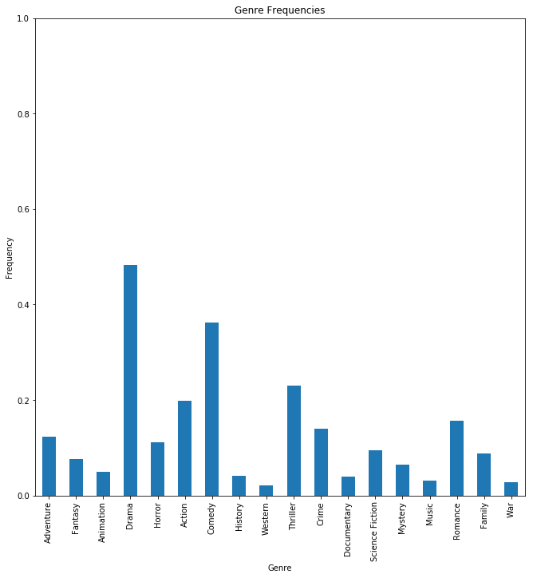

```python
pylab.rcParams['figure.figsize'] = (11, 11)
genre_frequencies = {k : ((float(v))/((genre.shape[0]))) for k,v in freq_dict.items()}
genre_frequencies_df = pd.DataFrame.from_dict(genre_frequencies,orient = "index")
genre_frequencies_df.plot(kind='bar', title='Genre Frequencies', ylim=(0.0,1.0), legend = False)
plt.xlabel('Genre')
plt.ylabel('Frequency')
plt.show()
```

#### Genre Correlation

Almost every movie has more than one genre. So we can see the relation between genres by finding their correlation.

```python
genre_for_correlation = genre.drop('tmdb_id', axis=1)
genre_correlation = genre_for_correlation.corr()
```

```python
genre_correlation
```

|  | Adventure | Fantasy | Animation | Drama | Horror | Action | Comedy | History | Western | Thriller | Crime | Documentary | Science Fiction | Mystery | Music | Romance | Family | War |
| --- | --- | --- | --- | --- | --- | --- | --- | --- | --- | --- | --- | --- | --- | --- | --- | --- | --- | --- |
| Adventure | 1.000000 | 0.199372 | 0.129254 | -0.142338 | -0.075234 | 0.334378 | -0.064501 | 0.010932 | 0.068795 | 0.017122 | -0.057231 | -0.069730 | 0.164394 | -0.041787 | -0.044454 | -0.066563 | 0.200928 | 0.029997 |
| Fantasy | 0.199372 | 1.000000 | 0.128582 | -0.123682 | 0.032352 | 0.039201 | -0.015545 | -0.047705 | -0.036411 | -0.058601 | -0.092227 | -0.056524 | 0.180820 | -0.012109 | -0.009467 | -0.009950 | 0.229958 | -0.043906 |
| Animation | 0.129254 | 0.128582 | 1.000000 | -0.175653 | -0.059532 | -0.018337 | -0.005317 | -0.044902 | -0.029894 | -0.105357 | -0.083811 | -0.046456 | 0.086380 | -0.043857 | 0.010965 | -0.071338 | 0.416411 | -0.018002 |
| Drama | -0.142338 | -0.123682 | -0.175653 | 1.000000 | -0.192686 | -0.133807 | -0.225194 | 0.149090 | -0.033392 | -0.005607 | 0.060816 | -0.162377 | -0.181995 | 0.027426 | 0.007396 | 0.198254 | -0.158172 | 0.113944 |
| Horror | -0.075234 | 0.032352 | -0.059532 | -0.192686 | 1.000000 | -0.038743 | -0.160829 | -0.062082 | -0.033232 | 0.215535 | -0.077482 | -0.058783 | 0.170747 | 0.120749 | -0.055222 | -0.137372 | -0.106564 | -0.056228 |
| Action | 0.334378 | 0.039201 | -0.018337 | -0.133807 | -0.038743 | 1.000000 | -0.114999 | 0.022891 | 0.095636 | 0.254867 | 0.144947 | -0.087823 | 0.188211 | -0.048327 | -0.066498 | -0.133958 | -0.073580 | 0.048813 |
| Comedy | -0.064501 | -0.015545 | -0.005317 | -0.225194 | -0.160829 | -0.114999 | 1.000000 | -0.131397 | -0.045816 | -0.287828 | -0.083205 | -0.130251 | -0.097628 | -0.135119 | 0.015733 | 0.146110 | 0.096735 | -0.090725 |
| History | 0.010932 | -0.047705 | -0.044902 | 0.149090 | -0.062082 | 0.022891 | -0.131397 | 1.000000 | 0.003033 | -0.074811 | -0.053461 | 0.001032 | -0.065657 | -0.041409 | -0.013716 | -0.013473 | -0.060534 | 0.337634 |
| Western | 0.068795 | -0.036411 | -0.029894 | -0.033392 | -0.033232 | 0.095636 | -0.045816 | 0.003033 | 1.000000 | -0.055512 | -0.035691 | -0.029741 | -0.039913 | -0.026204 | -0.014004 | -0.022199 | -0.032158 | -0.011325 |
| Thriller | 0.017122 | -0.058601 | -0.105357 | -0.005607 | 0.215535 | 0.254867 | -0.287828 | -0.074811 | -0.055512 | 1.000000 | 0.294472 | -0.109075 | 0.062771 | 0.301398 | -0.088345 | -0.137275 | -0.158174 | -0.035216 |
| Crime | -0.057231 | -0.092227 | -0.083811 | 0.060816 | -0.077482 | 0.144947 | -0.083205 | -0.053461 | -0.035691 | 0.294472 | 1.000000 | -0.073060 | -0.093193 | 0.149039 | -0.046009 | -0.093766 | -0.096210 | -0.059336 |
| Documentary | -0.069730 | -0.056524 | -0.046456 | -0.162377 | -0.058783 | -0.087823 | -0.130251 | 0.001032 | -0.029741 | -0.109075 | -0.073060 | 1.000000 | -0.062525 | -0.051155 | 0.070035 | -0.080229 | -0.047818 | -0.018180 |
| Science Fiction | 0.164394 | 0.180820 | 0.086380 | -0.181995 | 0.170747 | 0.188211 | -0.097628 | -0.065657 | -0.039913 | 0.062771 | -0.093193 | -0.062525 | 1.000000 | -0.000233 | -0.046902 | -0.086466 | 0.021243 | -0.044199 |
| Mystery | -0.041787 | -0.012109 | -0.043857 | 0.027426 | 0.120749 | -0.048327 | -0.135119 | -0.041409 | -0.026204 | 0.301398 | 0.149039 | -0.051155 | -0.000233 | 1.000000 | -0.037886 | -0.051095 | -0.061310 | -0.031348 |
| Music | -0.044454 | -0.009467 | 0.010965 | 0.007396 | -0.055222 | -0.066498 | 0.015733 | -0.013716 | -0.014004 | -0.088345 | -0.046009 | 0.070035 | -0.046902 | -0.037886 | 1.000000 | 0.076674 | 0.043220 | -0.019946 |
| Romance | -0.066563 | -0.009950 | -0.071338 | 0.198254 | -0.137372 | -0.133958 | 0.146110 | -0.013473 | -0.022199 | -0.137275 | -0.093766 | -0.080229 | -0.086466 | -0.051095 | 0.076674 | 1.000000 | -0.035612 | -0.000699 |
| Family | 0.200928 | 0.229958 | 0.416411 | -0.158172 | -0.106564 | -0.073580 | 0.096735 | -0.060534 | -0.032158 | -0.158174 | -0.096210 | -0.047818 | 0.021243 | -0.061310 | 0.043220 | -0.035612 | 1.000000 | -0.050225 |
| War | 0.029997 | -0.043906 | -0.018002 | 0.113944 | -0.056228 | 0.048813 | -0.090725 | 0.337634 | -0.011325 | -0.035216 | -0.059336 | -0.018180 | -0.044199 | -0.031348 | -0.019946 | -0.000699 | -0.050225 | 1.000000 |

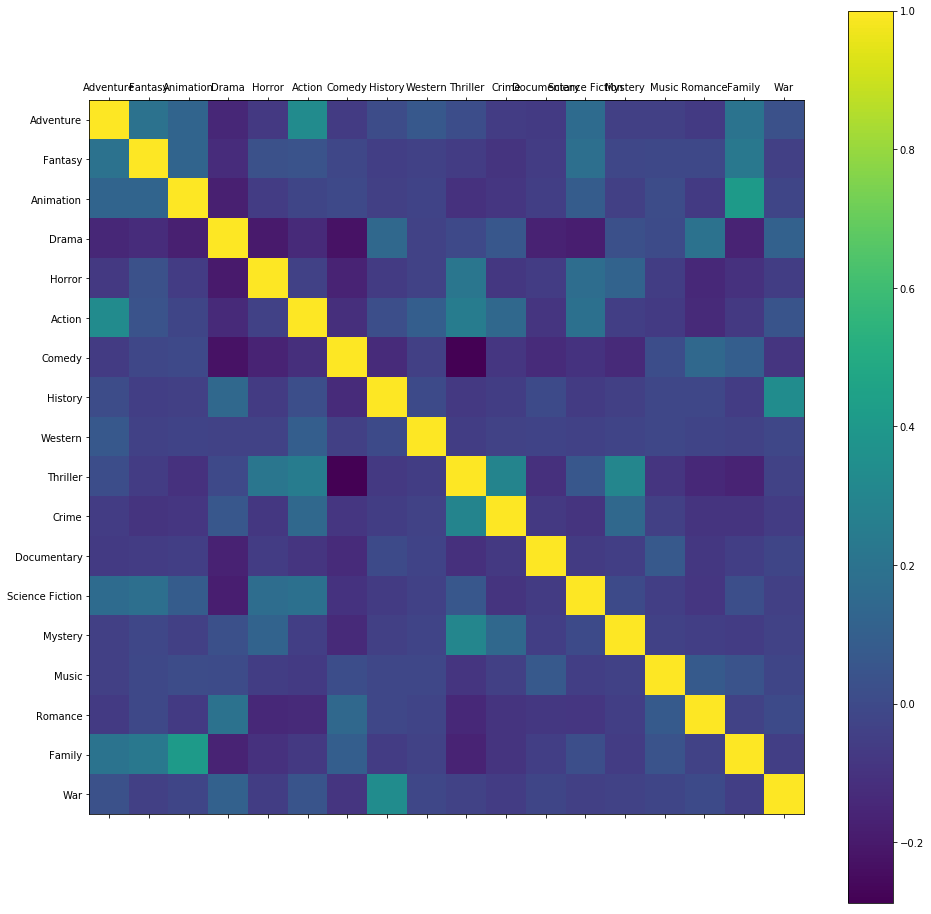

```python
pylab.rcParams['figure.figsize'] = (25, 25)
plt.matshow(genre_correlation)
plt.xticks(range(len(genre_for_correlation.columns)), genre_for_correlation.columns)
plt.yticks(range(len(genre_for_correlation.columns)), genre_for_correlation.columns)
plt.colorbar()
plt.show()
```

From the correlation matrix above, we notice some correlation between some genres like animation&family, crime&thriller, adventure&action.

#### Movie Info Correlation

```python
movies_for_correlation = movies[["budget", "revenue", "runtime", "popularity", "user_rating"]]
```

```python
movies_correlation = movies_for_correlation.corr()
```

```python
movies_correlation
```

|  | budget | revenue | runtime | popularity | user_rating |
| --- | --- | --- | --- | --- | --- |
| budget | 1.000000 | 0.718677 | 0.192698 | 0.564914 | 0.096397 |
| revenue | 0.718677 | 1.000000 | 0.169537 | 0.676534 | 0.133619 |
| runtime | 0.192698 | 0.169537 | 1.000000 | 0.202084 | 0.201615 |
| popularity | 0.564914 | 0.676534 | 0.202084 | 1.000000 | 0.282507 |
| user_rating | 0.096397 | 0.133619 | 0.201615 | 0.282507 | 1.000000 |

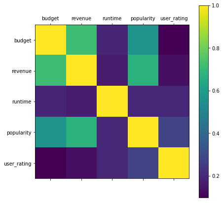

```python
pylab.rcParams['figure.figsize'] = (7, 7)
plt.matshow(movies_correlation)
plt.xticks(range(len(movies_for_correlation.columns)), movies_for_correlation.columns)
plt.yticks(range(len(movies_for_correlation.columns)), movies_for_correlation.columns)
plt.colorbar()
plt.show()
```

From the correlation matrix above, we notice some correlation between some values like budget and revenue, budget and popularity, popularity and revenue.

#### Wordcloud

```python
from wordcloud import WordCloud
```

```python
stopworddd = ['a', "a's", 'able', 'about', 'above', 'according',"film",'accordingly', 'across', 'actually', 'after', 'afterwards', 'again', 'against', "ain't", 'all', 'allow', 'allows', 'almost', 'alone', 'along', 'already', 'also', 'although', 'always', 'am', 'among', 'amongst', 'an', 'and', 'another', 'any', 'anybody', 'anyhow', 'anyone', 'anything', 'anyway', 'anyways', 'anywhere', 'apart', 'appear', 'appreciate', 'appropriate', 'are', "aren't", 'around', 'as', 'aside', 'ask', 'asking', 'associated', 'at', 'available', 'away', 'awfully', 'b', 'be', 'became', 'because', 'become', 'becomes', 'becoming', 'been', 'before', 'beforehand', 'behind', 'being', 'believe', 'below', 'beside', 'besides', 'best', 'better', 'between', 'beyond', 'both', 'brief', 'but', 'by', 'c', "c'mon", "c's", 'came', 'can', "can't", 'cannot', 'cant', 'cause', 'causes', 'certain', 'certainly', 'changes', 'clearly', 'co', 'com', 'come', 'comes', 'concerning', 'consequently', 'consider', 'considering', 'contain', 'containing', 'contains', 'corresponding', 'could', "couldn't", 'course', 'currently', 'd', 'definitely', 'described', 'despite', 'did', "didn't", 'different', 'do', 'does', "doesn't", 'doing', "don't", 'done', 'down', 'downwards', 'during', 'e', 'each', 'edu', 'eg', 'eight', 'either', 'else', 'elsewhere', 'enough', 'entirely', 'especially', 'et', 'etc', 'even', 'ever', 'every', 'everybody', 'everyone', 'everything', 'everywhere', 'ex', 'exactly', 'example', 'except', 'f', 'far', 'few', 'fifth', 'first', 'five', 'followed', 'following', 'follows', 'for', 'former', 'formerly', 'forth', 'four', 'from', 'further', 'furthermore', 'g', 'get', 'gets', 'getting', 'given', 'gives', 'go', 'goes', 'going',"things","electronic work","electronic","work",'gone', 'got', 'gotten', 'greetings', 'h', 'had', "hadn't", 'happens', 'hardly', 'has', "hasn't", 'have', "haven't", 'having', 'he', "he's", 'hello', 'help', 'hence', 'her', 'here', "here's", 'hereafter', 'hereby', 'herein', 'hereupon', 'hers', 'herself', 'hi', 'him', 'himself', 'his', 'hither', 'hopefully', 'how', 'howbeit', 'however', 'i', "i'd", "i'll", "i'm", "i've", 'ie', 'if', 'ignored', 'immediate', 'in', 'inasmuch', 'inc', 'indeed', 'indicate', 'indicated', 'indicates', 'inner', 'insofar', 'instead', 'into', 'inward', 'is', "isn't", 'it', "it'd", "it'll", "it's", 'its', 'itself', 'j', 'just', 'k', 'keep', 'keeps', 'kept', 'know', 'knows', 'known', 'l', 'last', 'lately', 'later', 'latter', 'latterly', 'least', 'less', 'lest', 'let', "let's", 'like', 'liked', 'likely', 'little', 'look', 'looking', 'looks', 'ltd', 'm', 'mainly', 'many', 'may', 'maybe', 'me', 'mean', 'meanwhile', 'merely', 'might', 'more', 'moreover', 'most', 'mostly', 'much', 'must', 'my', 'myself', 'n', 'name', 'namely', 'nd', 'near', 'nearly', 'necessary', 'need', 'needs', 'neither', 'never', 'nevertheless', 'new', 'next', 'nine', 'no', 'nobody', 'non', 'none', 'noone', 'nor', 'normally', 'not', 'nothing', 'novel', 'now', 'nowhere', 'o', 'obviously', 'of', 'off', 'often', 'oh', 'ok', 'okay', 'old', 'on', 'once', 'one', 'ones', 'only', 'onto', 'or', 'other', 'others', 'otherwise', 'ought', 'our', 'ours', 'ourselves', 'out', 'outside', 'over', 'overall', 'own', 'p', 'particular', 'particularly', 'per', 'perhaps', 'placed', 'please', 'plus', 'possible', 'presumably', 'probably', 'provides', 'q', 'que', 'quite', 'qv', 'r', 'rather', 'rd', 're', 'really', 'reasonably', 'regarding', 'regardless', 'regards', 'relatively', 'respectively', 'right', 's', 'said', 'same', 'saw', 'say', 'saying', 'says', 'second', 'secondly', 'see', 'seeing', 'seem', 'seemed', 'seeming', 'seems', 'seen', 'self', 'selves', 'sensible', 'sent', 'serious', 'seriously', 'seven', 'several', 'shall', 'she', 'should', "shouldn't", 'since', 'six', 'so', 'some', 'somebody', 'somehow', 'someone', 'something', 'sometime', 'sometimes', 'somewhat', 'somewhere', 'soon', 'sorry', 'specified', 'specify', 'specifying', 'still', 'sub', 'such', 'sup', 'sure', 't', "t's", 'take', 'taken', 'tell', 'tends', 'th', 'than', 'thank', 'thanks', 'thanx', 'that', "that's", 'thats', 'the', 'their', 'theirs', 'them', 'themselves', 'then', 'thence', 'there', "there's", 'thereafter', 'thereby',"place","moment", 'therefore', 'therein', 'theres', 'thereupon', 'these', 'they', "they'd", "they'll", "they're", "they've", 'think', 'third', 'this', 'thorough', 'thoroughly', 'those', 'though', 'three', 'through', 'throughout', 'thru', 'thus', 'to', 'together', 'too', 'took', 'toward', 'towards', 'tried', 'tries', 'truly', 'try', 'trying', 'twice', 'two', 'u', 'un', 'under', 'unfortunately', 'unless', 'unlikely', 'until', 'unto', 'up', 'upon', 'us', 'use', 'used', 'useful', 'uses', 'using', 'usually', 'uucp', 'v', 'value', 'various', 'very', 'via', 'viz', 'vs', 'w', 'want', 'wants', 'was', "wasn't", 'way', 'we', "we'd", "we'll", "we're", "we've", 'welcome', 'well', 'went', 'were', "weren't", 'what', "what's", 'whatever', 'when', 'whence', 'whenever', 'where', "where's", 'whereafter', 'whereas', 'whereby', 'wherein', 'whereupon', 'wherever', 'whether', 'which', 'while', 'whither', 'who', "who's", 'whoever', 'whole', 'whom', 'whose', 'why', 'will', 'willing', 'wish', 'with', 'within', 'without', "won't", 'wonder', 'would', 'would', "wouldn't", 'x', 'y', 'yes', 'yet', 'you', "you'd", "you'll", "you're", "you've", 'your', 'yours', 'yourself', 'yourselves', 'z', 'zero',"made","time","thing","man","hand","men","word","thought","day","electronic work","found"]

adjectives = ['able', 'bad', 'best',"back", 'better', 'big', 'black', 'certain', 'clear', 'early', 'easy', 'free', 'full', 'good', 'great', 'hard', 'high', 'important', 'large', 'late', 'little', 'local', 'long', 'low', 'major', 'new', 'old', 'only', 'other', 'political', 'possible', 'public', 'real', 'recent', 'right', 'small', 'social', 'special', 'strong', 'sure', 'true', 'white', 'whole', 'young']

common_verbs = ['say', 'make', 'go', 'take', 'come', 'see', 'know', 'get', 'give', 'find', 'think', 'tell', 'become', 'show', 'leave', 'feel', 'put', 'bring', 'begin', 'keep', 'hold', 'write', 'stand', 'hear', 'let', 'mean', 'set', 'meet', 'run', 'pay', 'sit', 'speak', 'lie', 'lead', 'read', 'grow', 'lose', 'fall', 'send', 'build', 'draw', 'break', 'spend', 'cut', 'rise', 'drive', 'buy', 'wear', 'choose', 'said', 'made', 'went', 'took', 'came', 'saw', 'knew', 'got', 'gavefound', 'thought', 'told', 'became', 'showed', 'left', 'felt', 'put', 'brought', 'began', 'kept', 'held', 'wrote', 'stood', 'heard', 'let', 'meant', 'set', 'met', 'ran', 'paid', 'sat', 'spoke', 'lay', 'led', 'read', 'grew', 'lost', 'fell', 'sent', 'built', 'drew', 'broke', 'spent', 'cut', 'rose', 'drove', 'bought', 'wore', 'chose', 'gone', 'taken', 'seen', 'known', 'given', 'shown', 'written', 'spoken', 'lain', 'grown', 'fallen', 'drawn', 'broken', 'risen', 'driven', 'worn', 'chosen', 'wanted', 'used', 'worked', 'called', 'tried', 'asked', 'needed', 'seemed', 'helped', 'played', 'moved', 'lived', 'believed', 'happened', 'included', 'continued', 'changed', 'watched', 'followed', 'stopped', 'created', 'opened', 'walked', 'offered', 'remembered', 'appeared', 'served', 'died', 'stayed', 'reached', 'killed', 'raised', 'passed', 'decided', 'returned', 'explained', 'hoped', 'carried', 'received', 'agreed', 'covered', 'caused', 'closed', 'increased', 'reduced', 'noted', 'entered', 'shared', 'saved', 'protected', 'occurred', 'accepted', 'determined', 'prepared', 'argued', 'recognized', 'indicated', 'arrived', 'answered', 'compared', 'acted', 'studied', 'removed', 'sounded', 'formed', 'visited', 'avoided', 'imagined', 'finished', 'responded', 'maintained', 'contained', 'applied', 'treated', 'affected', 'worried', 'mentioned', 'improved', 'signed', 'existed', 'noticed', 'travelled', 'prevented', 'admitted', 'suffered', 'published', 'counted', 'achieved', 'announced', 'touched', 'attended', 'defined', 'introduced']

final_stopwords = stopworddd + adjectives + common_verbs
```

```
Action
```

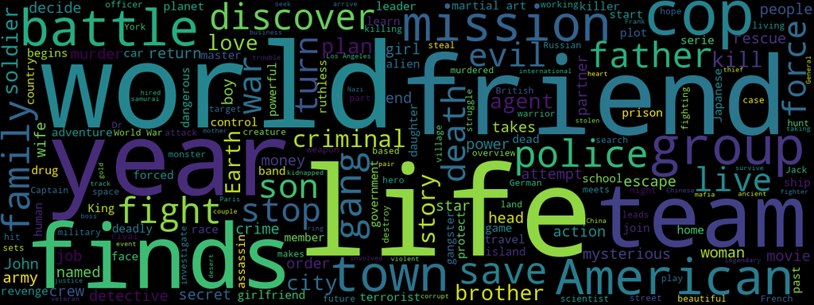

```python
movies_for_wordcloud = movies[["tmdb_id","plot"]]
genre_movies_for_wordcloud = genre[["tmdb_id","Action"]]
merged_for_wordcloud = pd.merge(movies_for_wordcloud, genre_movies_for_wordcloud, on='tmdb_id')
merged_for_wordcloud = merged_for_wordcloud[merged_for_wordcloud.Action != 0]
values = " ".join(map(str, (merged_for_wordcloud["plot"].tolist())))
print("Action")
WordCloud(stopwords=final_stopwords,width=1200,height=450).generate(values).to_image()
```

```
Comedy
```

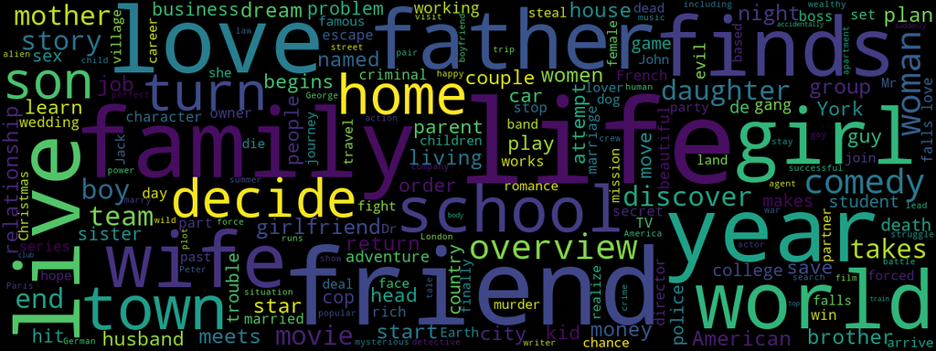

```python
movies_for_wordcloud = movies[["tmdb_id","plot"]]
genre_movies_for_wordcloud = genre[["tmdb_id","Comedy"]]
merged_for_wordcloud = pd.merge(movies_for_wordcloud, genre_movies_for_wordcloud, on='tmdb_id')
merged_for_wordcloud = merged_for_wordcloud[merged_for_wordcloud.Comedy != 0]
values = " ".join(map(str, (merged_for_wordcloud["plot"].tolist())))
print("Comedy")
WordCloud(stopwords=final_stopwords,width=1200,height=450).generate(values).to_image()
```

```
Western
```

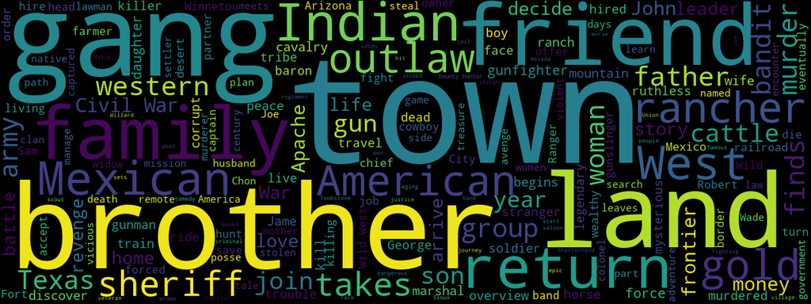

```python
movies_for_wordcloud = movies[["tmdb_id","plot"]]
genre_movies_for_wordcloud = genre[["tmdb_id","Western"]]
merged_for_wordcloud = pd.merge(movies_for_wordcloud, genre_movies_for_wordcloud, on='tmdb_id')
merged_for_wordcloud = merged_for_wordcloud[merged_for_wordcloud.Western != 0]
values = " ".join(map(str, (merged_for_wordcloud["plot"].tolist())))
print("Western")
WordCloud(stopwords=final_stopwords,width=1200,height=450).generate(values).to_image()
```

```
Fantasy
```

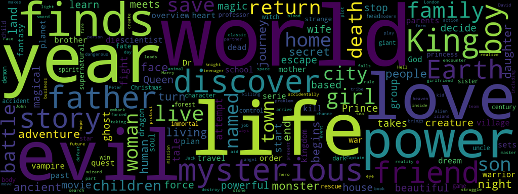

```python
movies_for_wordcloud = movies[["tmdb_id","plot"]]
genre_movies_for_wordcloud = genre[["tmdb_id","Fantasy"]]
merged_for_wordcloud = pd.merge(movies_for_wordcloud, genre_movies_for_wordcloud, on='tmdb_id')
merged_for_wordcloud = merged_for_wordcloud[merged_for_wordcloud.Fantasy != 0]
values = " ".join(map(str, (merged_for_wordcloud["plot"].tolist())))
print("Fantasy")
WordCloud(stopwords=final_stopwords,width=1200,height=450).generate(values).to_image()
```

```
Animation
```

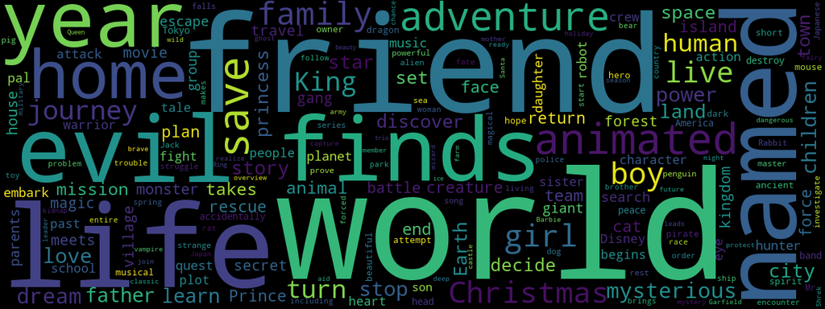

```python
movies_for_wordcloud = movies[["tmdb_id","plot"]]
genre_movies_for_wordcloud = genre[["tmdb_id","Animation"]]
merged_for_wordcloud = pd.merge(movies_for_wordcloud, genre_movies_for_wordcloud, on='tmdb_id')
merged_for_wordcloud = merged_for_wordcloud[merged_for_wordcloud.Animation != 0]
values = " ".join(map(str, (merged_for_wordcloud["plot"].tolist())))
print("Animation")
WordCloud(stopwords=final_stopwords,width=1200,height=450).generate(values).to_image()
```

```
Science Fiction
```

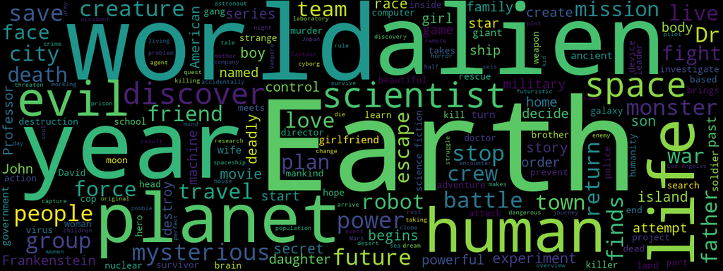

```python
movies_for_wordcloud = movies[["tmdb_id","plot"]]
genre_movies_for_wordcloud = genre[["tmdb_id","Science Fiction"]]
merged_for_wordcloud = pd.merge(movies_for_wordcloud, genre_movies_for_wordcloud, on='tmdb_id')
merged_for_wordcloud = merged_for_wordcloud[merged_for_wordcloud["Science Fiction"] != 0]
values = " ".join(map(str, (merged_for_wordcloud["plot"].tolist())))
print("Science Fiction")
WordCloud(stopwords=final_stopwords,width=1200,height=450).generate(values).to_image()
```

```
Crime
```

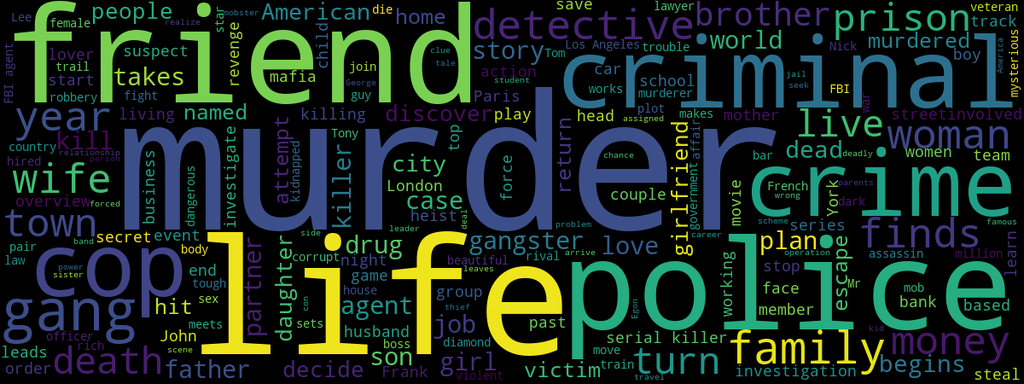

```python
movies_for_wordcloud = movies[["tmdb_id","plot"]]
genre_movies_for_wordcloud = genre[["tmdb_id","Crime"]]
merged_for_wordcloud = pd.merge(movies_for_wordcloud, genre_movies_for_wordcloud, on='tmdb_id')
merged_for_wordcloud = merged_for_wordcloud[merged_for_wordcloud.Crime != 0]
values = " ".join(map(str, (merged_for_wordcloud["plot"].tolist())))
print("Crime")
WordCloud(stopwords=final_stopwords,width=1200,height=450).generate(values).to_image()
```

We can see that, the wordcloud vary according to the genre of films and we can notice some keyword based on label that makes sense.

## Evaluation and Future Plans

I spent a lot of time trying to create the dataset myself at the beginning of the project. I would have been ahead of my current position if I was dealing with a direct dataset instead of dealing with APIs with a request limit per time period.

I will try to transform the data set into numeric features in the future phases of the project. As can be seen from the wordclouds, movie names and movie summaries have very important values, so I'll try to translate this text-based data into numerical data in order to be able to use them effectively. I will also perform one-hot-encoding to use the people and rating (R, PG13) of movie as we see in "Handling Text and Categorical Attributes" parts in Chapter 2.

Then I will start using different Machine Learning algorithms and evaulate their accuracy.